# Principal Component Analysis (PCA)

Created By Julio SOLANO

Sep 07, 2018

# Setup

```r
 set.seed(111)
```

# Loading Libraries

```r
library(factoextra)              # fviz_eig, fviz_pca_var, get_pca_var functions
library(psych)                   # fa.parallel function
library(PerformanceAnalytics)    # chart.Correlation
library(REdaS)                   # bart_spher & KMOS functions
library(ggplot2)
library(corrplot)                # corrplot function
library(gridExtra)               # grid.arrange function
library(kableExtra)

#Organizing Packge information for table
packages <- c("factoextra", "psych", "PerformanceAnalytics", "REdaS", "ggplot2", "corrplot", "gridExtra", "kableExtra")
display <- c("Package","Title", "Maintainer", "Version", "URL")
table <- matrix(NA, 1, NROW(display), dimnames = list(1, display))
for(i in 1:NROW(packages)){
list <- packageDescription(packages[i])
table <- rbind(table, matrix(unlist(list[c(display)]), 1, NROW(display), byrow = T))
}
table[,NROW(display)] <- stringr::str_extract(table[,NROW(display)], ".+,")

#Table of packages
kable(table[-1,], format = "html", align = "c") %>%
  kable_styling(bootstrap_options = c("striped", "hover", "condensed"))
```

|  | Package | Title | Maintainer | Version | URL |
| --- | --- | --- | --- | --- | --- |
|  | factoextra | Extract and Visualize the Results of Multivariate Data Analyses | Alboukadel Kassambara <alboukadel.kassambara@gmail.com>; | 1.0.5 | NA |
|  | psych | Procedures for Psychological, Psychometric, and Personality Research | William Revelle <revelle@northwestern.edu>; | 1.8.4 | NA |
|  | PerformanceAnalytics | Econometric Tools for Performance and Risk Analysis | Brian G. Peterson <brian@braverock.com>; | 1.5.2 | NA |
|  | REdaS | Companion Package to the Book ‘R: Einführung durch angewandte Statistik’ | Marco Johannes Maier <marco.maier@wu.ac.at>; | 0.9.3 | NA |
|  | ggplot2 | Create Elegant Data Visualisations Using the Grammar of Graphics | Hadley Wickham <hadley@rstudio.com>; | 3.0.0 | http://ggplot2.tidyverse.org, |
|  | corrplot | Visualization of a correlation matrix | Taiyun Wei <weitaiyun@gmail.com>; | 0.73 | NA |
|  | gridExtra | functions in Grid graphics | baptiste <baptiste.auguie@gmail.com>; | 0.9.1 | NA |
|  | kableExtra | Construct Complex Table with ‘kable’ and Pipe Syntax | Hao Zhu <haozhu233@gmail.com>; | 0.9.0 | http://haozhu233.github.io/kableExtra/, |

# Problem Definition

Este estudio recoge la composición y características físico-químicas de 276 acuíferos del Etna (Sicilia) y fue publicado en Aiuppa, A., Bellomo, S., Brusca, L., D’Alessandro, W., Federico, C. (2003) Natural and anthropogenic factors affecting groundwater quality of an active volcano (Mt. Etna, Italy). Applied Geochemistry, 18, 863–882.

El objetivo de este estudio es entender la procedencia de los diferentes tipos de aguas del Monte Etna y gestionar adecuadamente los recursos hídricos de Sicilia (Italia).

# Exercise 1: Data Source

```r
acuiferos.raw <- read.csv("acuiferos.csv", header=T, sep = ",")

temp <- subset(acuiferos.raw, select=c(1,2,3,4,6,7,8,9,10,11,12,13,14,15,19))

temp$Date <- as.Date(temp$Date,'%d-%m-%y')
acuiferos <- na.omit(temp)

str(acuiferos)
```

```
## 'data.frame':    232 obs. of  15 variables:
##  $ Sample: Factor w/ 246 levels " agnara"," ellia",..: 210 91 8 39 92 99 207 31 197 183 ...
##  $ Date  : Date, format: "1997-01-16" "1997-04-09" ...
##  $ T     : num  15 10.2 12.2 10.7 14.1 10.9 14.1 11.2 13 15.5 ...
##  $ pH    : num  6.52 6.62 7.3 6.67 7.5 6.7 7.57 7.4 7.99 7.6 ...
##  $ Na    : num  110 40.7 55.9 69.7 52.4 46.9 37.9 21.8 64.9 65.8 ...
##  $ K     : num  18.8 7 12.1 12.5 10.2 9 8.4 3.1 11.3 10.9 ...
##  $ Mg    : num  44.5 21.7 29.2 41.8 22.2 24.4 11.8 7 19.1 20.7 ...
##  $ Ca    : num  46.7 34.7 89.6 42.5 23.2 63.5 21.9 51.5 15.7 8.2 ...
##  $ Alk   : num  519 256 354 415 226 299 177 189 195 232 ...
##  $ Cl    : num  47.1 20.5 62.9 32.9 28.8 39.8 24.5 17.5 30.1 30.8 ...
##  $ NO3   : num  6.26 3.41 40.2 8.25 12 24.9 4.09 7.56 1.61 3.04 ...
##  $ SO4   : num  79.2 34.3 79.2 46 40.4 52.3 23.9 23.9 71.5 26.8 ...
##  $ SiO2  : int  62 31 37 40 37 35 39 19 30 36 ...
##  $ TDS   : int  933 449 760 708 452 595 349 340 439 434 ...
##  $ B     : num  190 145 130 230 187 136 171 100 133 274 ...
##  - attr(*, "na.action")= 'omit' Named int  1 3 10 12 14 21 22 24 31 32 ...
##   ..- attr(*, "names")= chr  "1" "3" "10" "12" ...
```

```r
head(acuiferos, 10)
```

```
##         Sample       Date    T   pH    Na    K   Mg   Ca Alk   Cl   NO3
## 2           S. 1997-01-16 15.0 6.52 110.0 18.8 44.5 46.7 519 47.1  6.26
## 4      Fisuari 1997-04-09 10.2 6.62  40.7  7.0 21.7 34.7 256 20.5  3.41
## 5  Acquafredda 1997-04-28 12.2 7.30  55.9 12.1 29.2 89.6 354 62.9 40.20
## 6      Cambria 1997-04-28 10.7 6.67  69.7 12.5 41.8 42.5 415 32.9  8.25
## 7  Fiumefreddo 1997-04-28 14.1 7.50  52.4 10.2 22.2 23.2 226 28.8 12.00
## 8     Gabbella 1997-04-28 10.9 6.70  46.9  9.0 24.4 63.5 299 39.8 24.90
## 9   Rovittello 1997-04-29 14.1 7.57  37.9  8.4 11.8 21.9 177 24.5  4.09
## 11     Biviere 1997-04-30 11.2 7.40  21.8  3.1  7.0 51.5 189 17.5  7.56
## 13    Ragonese 1997-04-30 13.0 7.99  64.9 11.3 19.1 15.7 195 30.1  1.61
## 15    Picciolo 1997-05-05 15.5 7.60  65.8 10.9 20.7  8.2 232 30.8  3.04
##     SO4 SiO2 TDS   B
## 2  79.2   62 933 190
## 4  34.3   31 449 145
## 5  79.2   37 760 130
## 6  46.0   40 708 230
## 7  40.4   37 452 187
## 8  52.3   35 595 136
## 9  23.9   39 349 171
## 11 23.9   19 340 100
## 13 71.5   30 439 133
## 15 26.8   36 434 274
```

# Exercise 2: Matrix Correlation

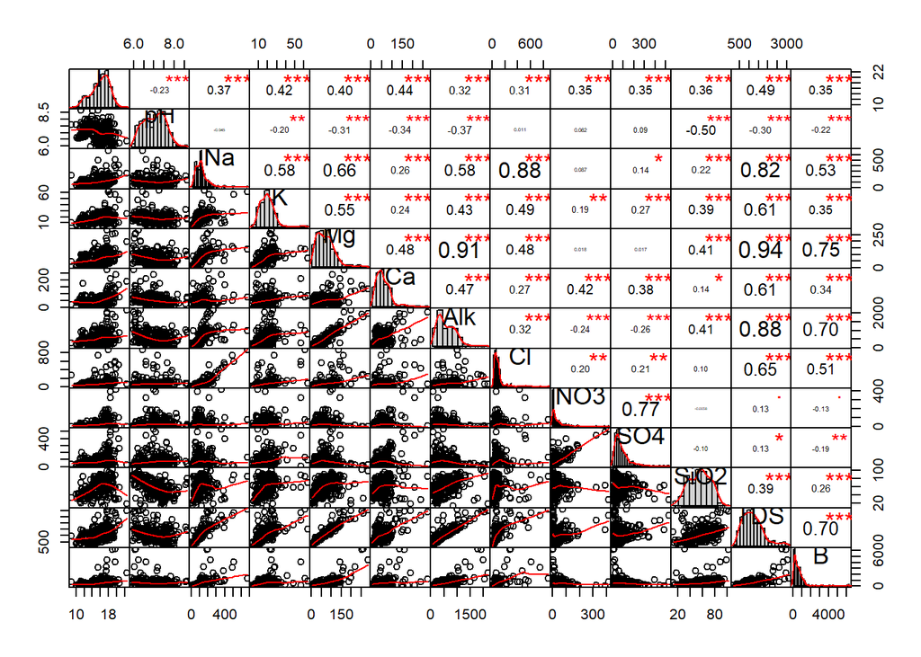

```r
chart.Correlation(acuiferos[, 3:15], histogram=TRUE, pch="*", method = c("spearman"))
```

De la matriz de correlación se puede destacar: (1) la alta correlación (lineal) entre el Na-Cl-TDS, y una menor relación de éstos con el K-Mg-Alk; (2) la media correlación (lineal) entre NO3 – SO4. El grafico de dispersión muestra estas asociaciones lineales y descubre la relación no-lineal entre el B – SO4.

# Exercise 3: Bartlett’s Test of Sphericity & KMO Test

```r
REdaS::bart_spher(acuiferos[, 3:15], use = "complete.obs")
```

```
##  Bartlett's Test of Sphericity
##
## Call: REdaS::bart_spher(x = acuiferos[, 3:15], use = "complete.obs")
##
##      X2 = 5933.273
##      df = 78
## p-value < 2.22e-16
```

```r
REdaS::KMOS(acuiferos[, 3:15], use = "complete.obs")
```

```
##
## Kaiser-Meyer-Olkin Statistics
##
## Call: REdaS::KMOS(x = acuiferos[, 3:15], use = "complete.obs")
##
## Measures of Sampling Adequacy (MSA):
##         T        pH        Na         K        Mg        Ca       Alk
## 0.8743366 0.9957474 0.2594872 0.1916959 0.3059259 0.1670320 0.2800644
##        Cl       NO3       SO4      SiO2       TDS         B
## 0.2051925 0.1072485 0.1132621 0.1168193 0.3342401 0.9592753
##
## KMO-Criterion: 0.2490432
```

Los resultados del test de Bartlett indican que el p value is < 0.000, esto es estadisticamente significativo, por tanto, se rechaza la Ho (matriz de correlacion es la matriz identidad), PCA puede ser implementado. Los resultados para el test KMO de adecuación muestreal no son muy alentadores, con KMO = 0.249 (Bad).

# Exercise 4: PCA Model

```r
pca.model <- prcomp(acuiferos[, 3:15], center=TRUE, scale=TRUE)
summary(pca.model)
```

```
## Importance of components:
##                           PC1    PC2    PC3     PC4     PC5     PC6
## Standard deviation     2.3946 1.5347 1.2340 0.98918 0.77290 0.73554
## Proportion of Variance 0.4411 0.1812 0.1171 0.07527 0.04595 0.04162
## Cumulative Proportion  0.4411 0.6223 0.7394 0.81468 0.86063 0.90225
##                            PC7     PC8     PC9   PC10    PC11    PC12
## Standard deviation     0.65037 0.59297 0.50510 0.4297 0.23272 0.04740
## Proportion of Variance 0.03254 0.02705 0.01963 0.0142 0.00417 0.00017
## Cumulative Proportion  0.93479 0.96183 0.98146 0.9957 0.99983 1.00000
##                             PC13
## Standard deviation     0.0008375
## Proportion of Variance 0.0000000
## Cumulative Proportion  1.0000000
```

El primer valor se debe a la varianza explicada, en tanto por uno, (0.441) del primer componente sin rotar; 0.181 es la varianza explicada por el segundo componente (sin rotar); y sucesivamente. La matriz de componentes nos informa de la relación entre las variables, agrupándolas y por lo tanto, reduciendo la cantidad de datos originales.

# Exercise 5: Parallel Analysis

El Análisis Paralelo (AP) selecciona los componentes o factores comunes que presentan valores propios mayores que los que se obtendrían por azar (Horn, 1965). La idea es: si la matriz analizada procediera de una población en que los ítems no estuvieran relacionados, ¿qué valores propios podrían alcanzar los factores comunes extraídos de esa matriz? Y ¿cuántos factores comunes de los que hemos obtenido sobre la matriz analizada superan esos valores propios “espurios”? La respuesta a esta pregunta ofrece el número correcto de factores comunes.

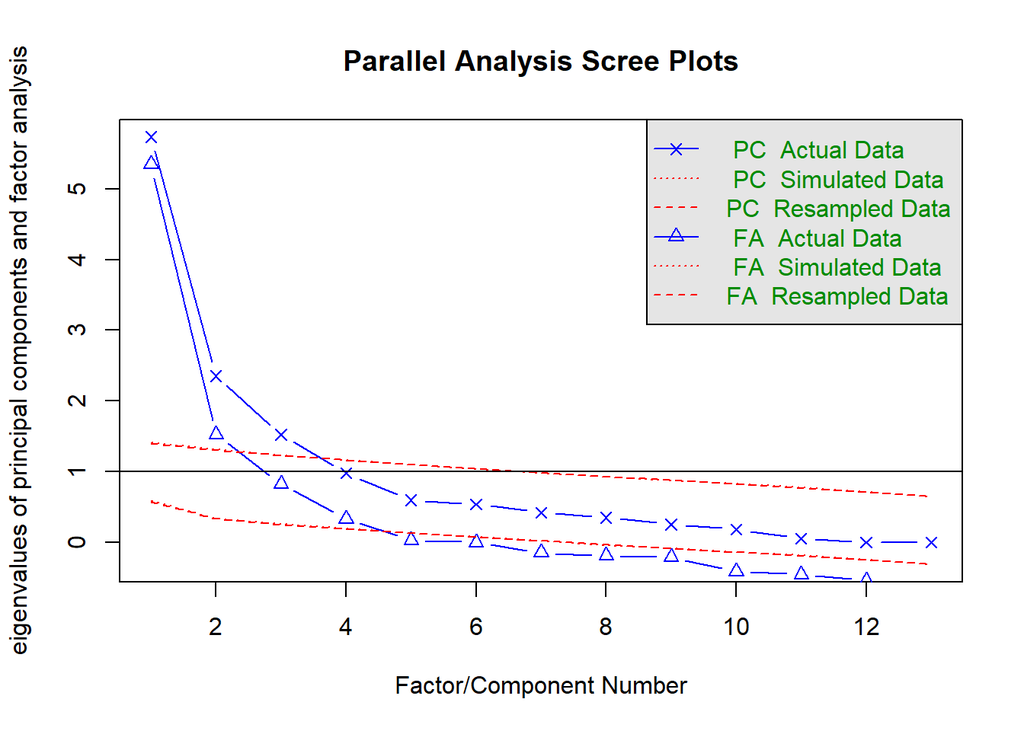

```
## Parallel analysis suggests that the number of factors =  4  and the number of components =  3
```

```r
psych::fa.parallel(acuiferos[, 3:15], fa="both", n.iter=50, error.bars=FALSE, sim=TRUE, quant=.95, cor="cor", show.legend=TRUE, main="Parallel Analysis Scree Plots")
```

# Exercise 6: Scree Plot

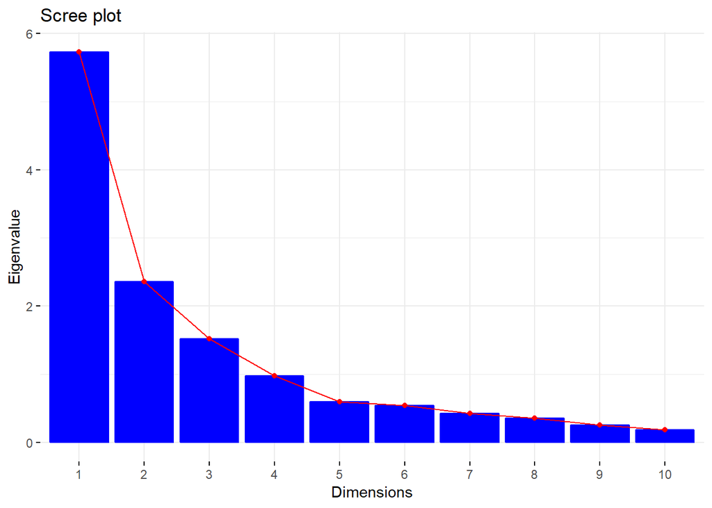

```r
factoextra::fviz_eig(pca.model, "eigenvalue", barfill = "blue", barcolor = "blue", linecolor = "red")
```

# Exercise 7: Biplot

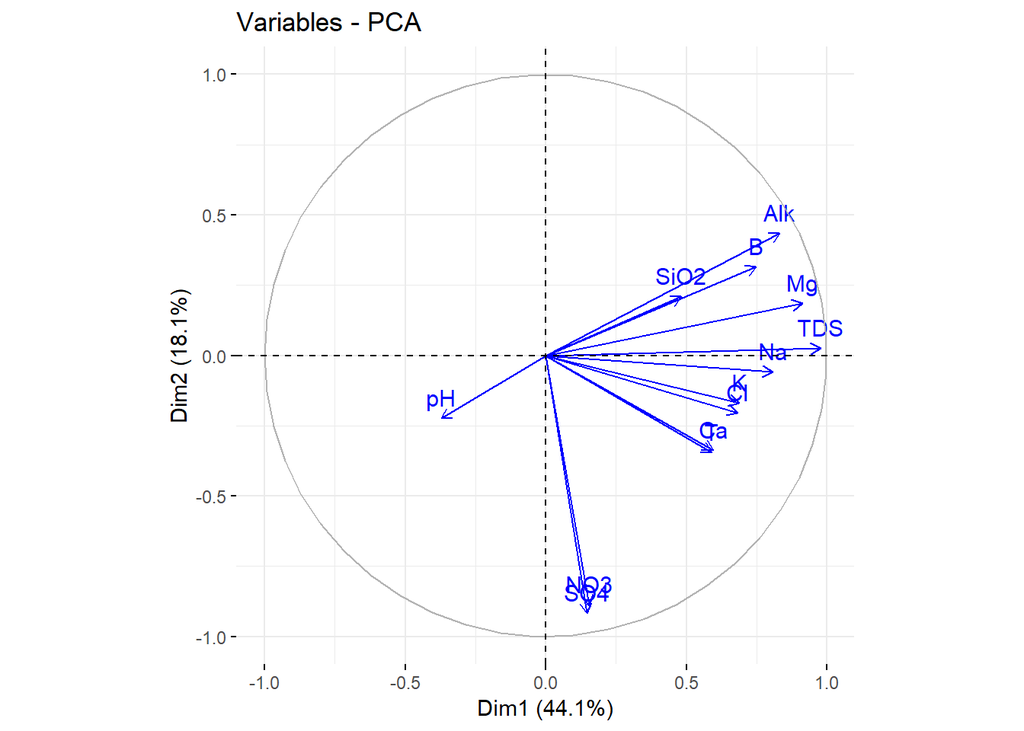

```r
factoextra::fviz_pca_var(pca.model, col.var = "blue")
```

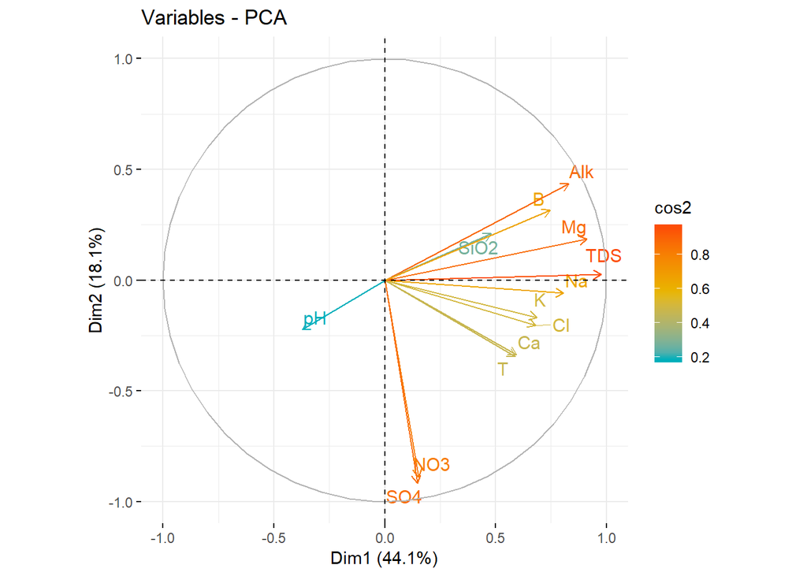

```r
factoextra::fviz_pca_var(pca.model, col.var = "cos2", gradient.cols = c("#00AFBB","#E7B800","#FC4E07"), repel = T)
```

```r
pca.model$rotation[, 1:3]
```

```
##              PC1         PC2          PC3
## T     0.24630216 -0.22574606 -0.223858274
## pH   -0.15536131 -0.14620243  0.571004071
## Na    0.33664894 -0.03853952  0.381454677
## K     0.28677882 -0.10958623  0.033809081
## Mg    0.38063118  0.12118767  0.007911266
## Ca    0.24825768 -0.21923221 -0.271086945
## Alk   0.34673880  0.28412904 -0.052380453
## Cl    0.28440388 -0.13278529  0.432884105
## NO3   0.06400397 -0.57885279 -0.113811596
## SO4   0.06148144 -0.59711112 -0.048704328
## SiO2  0.20126610  0.13630893 -0.424390551
## TDS   0.40790377  0.01669667  0.055296072
## B     0.31181433  0.20636745  0.122547269
```

# Exercise 8: Contribution to the Principal Components

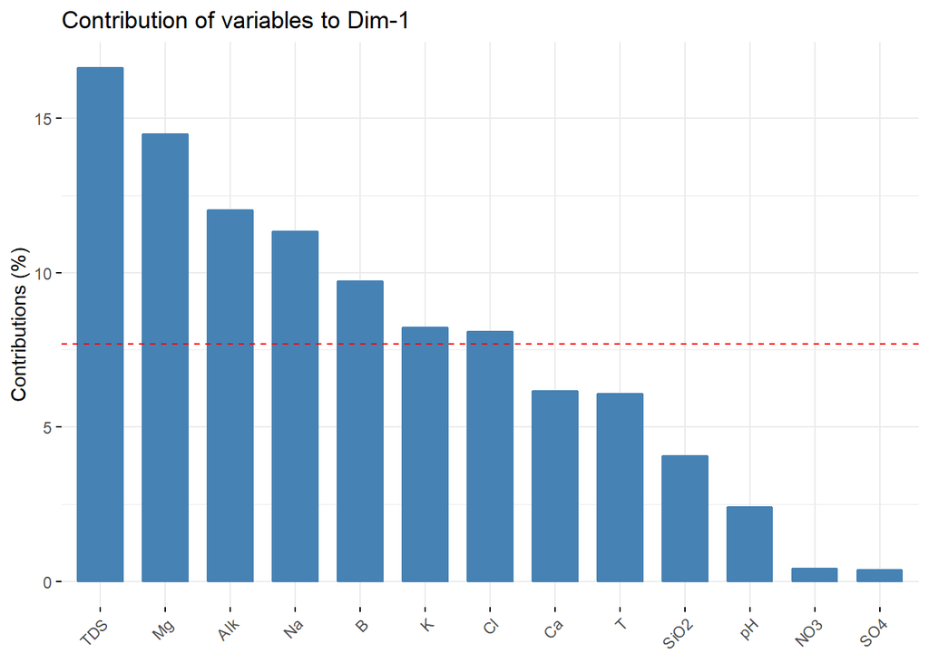

```r
var <- get_pca_var(pca.model)
a <- fviz_contrib(pca.model, "var", axes = 1)
a
```

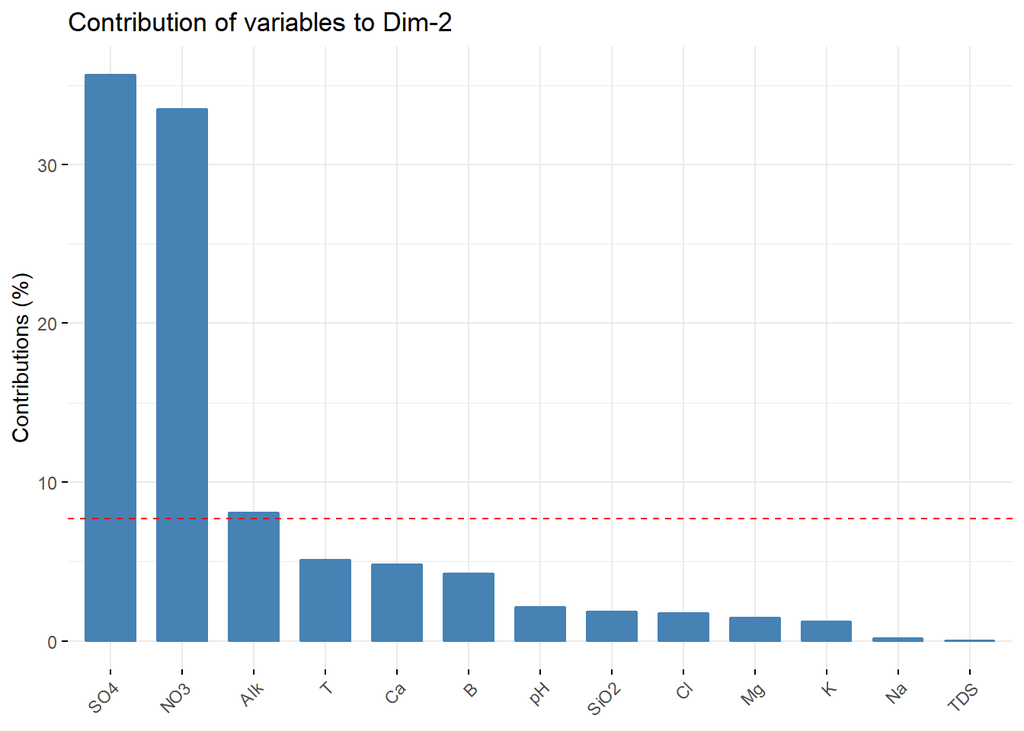

```r
b <- fviz_contrib(pca.model, "var", axes = 2)
b
```

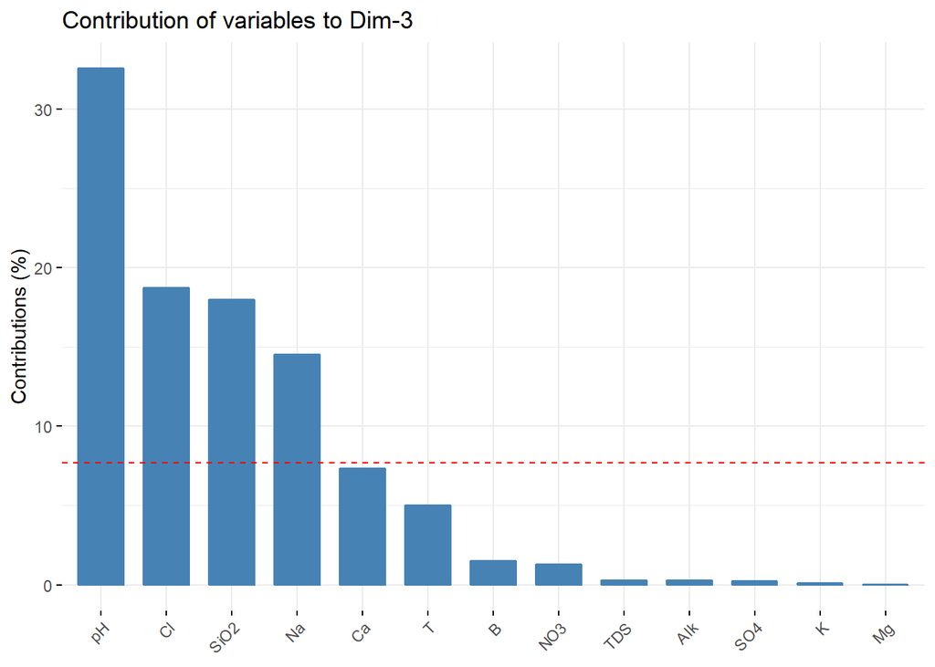

```r
c <- fviz_contrib(pca.model, "var", axes = 3)
c
```

# Exercise 8: Contribution to the Principal Components

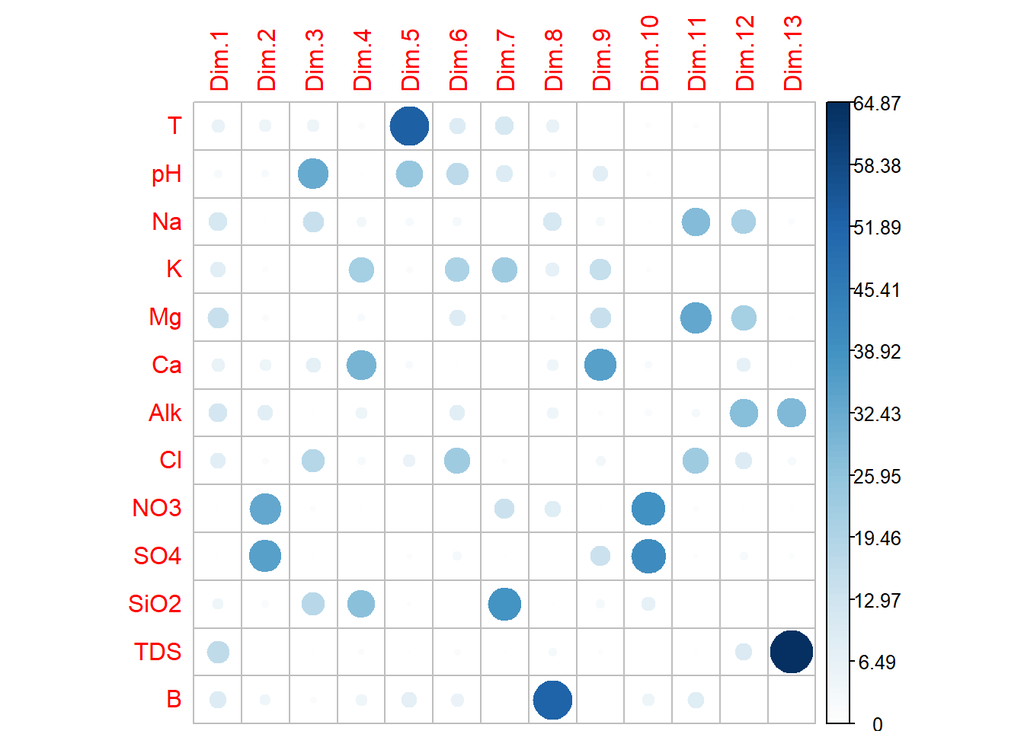

```r
corrplot(var$contrib, is.corr = F)
```

# Exercise 9: Analisis de los Componentes

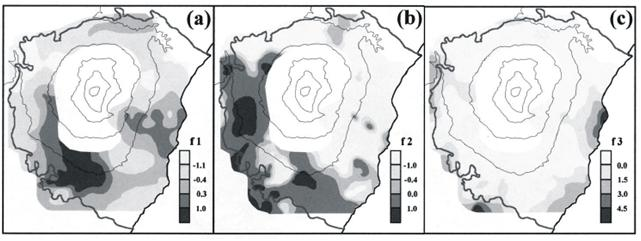

Mapa de distribuciones de los tres factores obtenidos en el ACP. (en Aiuppa, A., Bellomo, S., Brusca, L., D’Alessandro, W., Federico, C. (2003) Natural and anthropogenic factors affecting groundwater quality of an active volcano - Mt. Etna, Italy. Applied Geochemistry, 18, 863–882).

# Exercise 10 (optional): Hierarchical Clustering on Principal Components (HCPC)

El análisis factorial y el analisis de componentes principales en conjunto con la agrupación jerárquica, son herramientas muy complementarias para explorar datos.

En el caso de un conjunto de datos multidimensionales que contienen variables continuas, el análisis de componentes principales (PCA) se puede utilizar para reducir la dimensionalidad de los datos en pocas variables continuas (es decir, componentes principales) que contienen la información más importante en los datos. El paso de PCA se puede considerar como un paso de eliminación de ruido que puede conducir a un agrupamiento más estable. Esto es muy útil si tiene un gran conjunto de datos con múltiples variables.

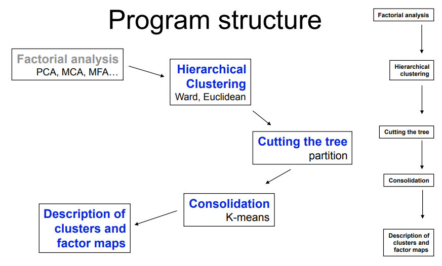

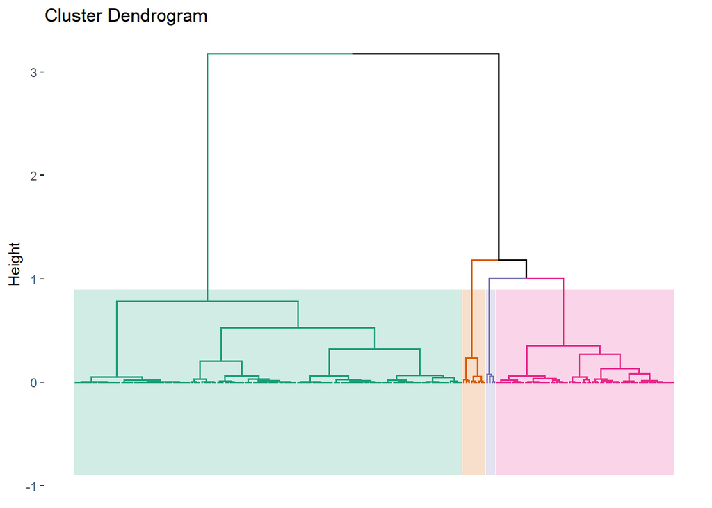

```r
library(FactoMineR)
pca.model2 = FactoMineR::PCA(acuiferos[, 3:15], ncp = 3, graph = FALSE)
hcpc <- FactoMineR::HCPC(pca.model2, graph = FALSE)

factoextra::fviz_dend(hcpc, cex = 0.8, palette = "Dark2", rect = T, rect_fill = T, rect_border = "Dark2", show_labels = F) #takes too long
```

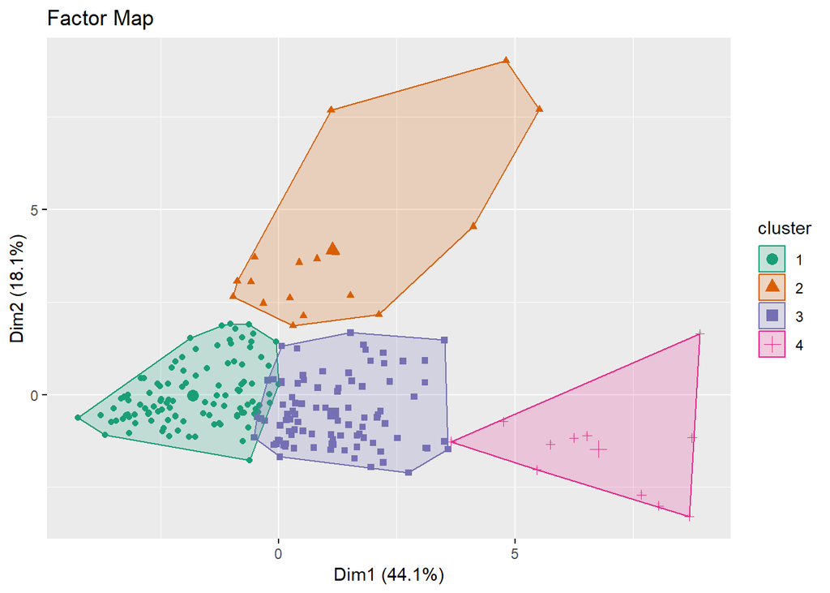

```r
factoextra::fviz_cluster(hcpc, palette = "Dark2", show.clust.cent = T, main = "Factor Map", labelsize = 1)
```